# Closed Testing Procedure

## Another hypothesis structure

Testing the elementary hypotheses 1:2, 2:3, 3:4 simultaneously using the F-Test, i.e. testing $H_1: \mu_1=\mu_2$, $H_2: \mu_2=\mu_3$ and $H_3: \mu_3=\mu_4$ simultaneously. This provides quite different results (compared to pasi.ctp.F1): No further improvement for higher doses.

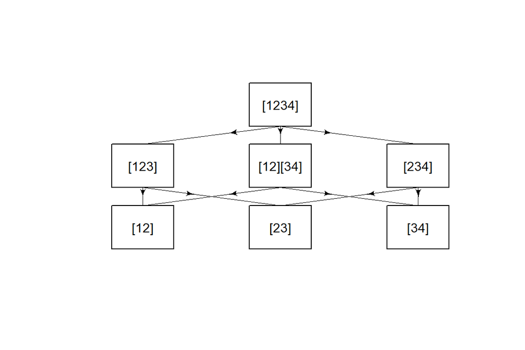

```r
dose.steps4 <- IntersectHypotheses(list(1:2,2:3,3:4))
Display(dose.steps4,arr=TRUE)
```

```r
pasi.ctp.F2 <- AnalyseCTP(dose.steps4,pasi.ch~dose,pasi)
summary(pasi.ctp.F2)
```

```
##
## Summary of Closed Testing Procedure
## ===================================
##
## Model : pasi.ch ~ dose , test : F
##
## Factor levels: 1=Placebo, 2=ET.10mg, 3=ET.25mg, 4=ET.50mg
##
## Hypotheses and p-values
## -----------------------
##
##  Hypothesis Level raw p-value adj. p-value
##        [12]     1   4.748e-03    1.506e-02
##        [23]     1   1.139e-01    1.139e-01
##        [34]     1   5.257e-01    5.257e-01
##       [123]     2   1.063e-04    1.063e-04
##    [12][34]     2   1.506e-02    1.506e-02
##       [234]     2   7.205e-02    7.205e-02
##      [1234]     3   6.542e-06    6.542e-06
```

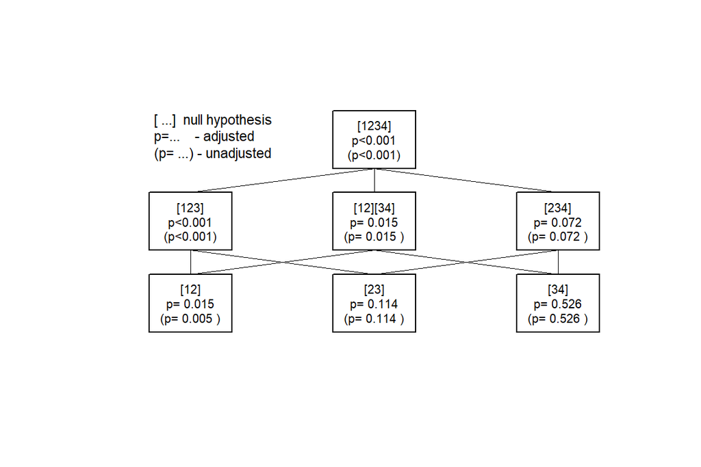

```r
Display(pasi.ctp.F2)
```

## Other tests

For the same hypotheis structure, other tests can also be used:

### Kruskal-Wallis test of trend for all single hypotheses

```r
pasi.ctp.K <- AnalyseCTP(dose.steps4,pasi.ch~dose,pasi, test="kruskal")
summary(pasi.ctp.K)
```

```
##
## Summary of Closed Testing Procedure
## ===================================
##
## Model : pasi.ch ~ dose , test : kruskal
##
## Factor levels: 1=Placebo, 2=ET.10mg, 3=ET.25mg, 4=ET.50mg
##
## Hypotheses and p-values
## -----------------------
##
##  Hypothesis Level raw p-value adj. p-value
##        [12]     1   2.350e-02    5.605e-02
##        [23]     1   1.655e-01    1.655e-01
##        [34]     1   4.255e-01    4.255e-01
##       [123]     2   1.466e-03    1.466e-03
##    [12][34]     2   5.605e-02    5.605e-02
##       [234]     2   6.988e-02    6.988e-02
##      [1234]     3   7.557e-05    7.557e-05
```

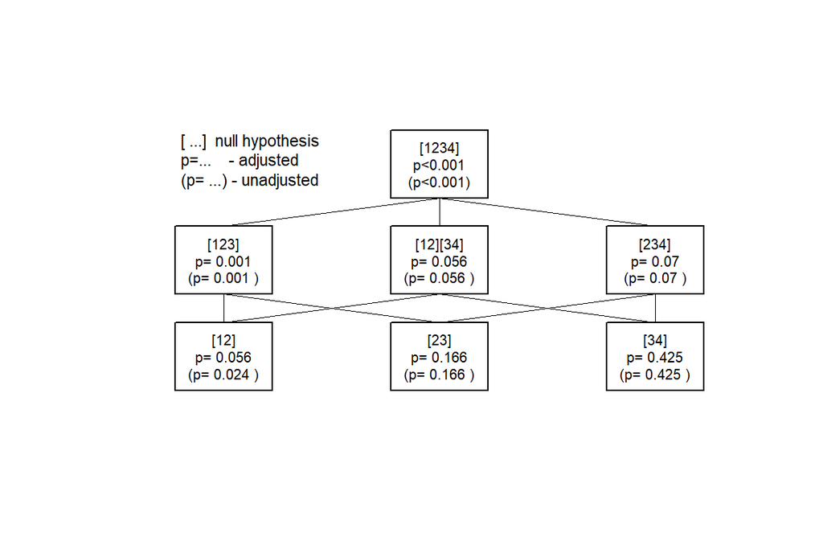

```r
Display(pasi.ctp.K)
```

### Jonckheere-Terpstra test of trend for all single hypotheses

```r
pasi.ctp.J1 <- AnalyseCTP(dose.steps4,pasi.ch~dose,pasi, test="jonckheere",alternative="increasing")
pasi.ctp.J2 <- AnalyseCTP(dose.steps4,pasi.ch~dose,pasi, test="jonckheere",alternative="two.sided")
summary(pasi.ctp.J1)
```

```
##
## Summary of Closed Testing Procedure
## ===================================
##
## Model : pasi.ch ~ dose , test : jonckheere
##
## Factor levels: 1=Placebo, 2=ET.10mg, 3=ET.25mg, 4=ET.50mg
##
## Hypotheses and p-values
## -----------------------
##
##  Hypothesis Level raw p-value adj. p-value
##        [12]     1   1.179e-02    5.652e-02
##        [23]     1   8.284e-02    8.284e-02
##        [34]     1   2.141e-01    2.141e-01
##       [123]     2   1.563e-04    1.563e-04
##    [12][34]     2   5.652e-02    5.652e-02
##       [234]     2   1.189e-02    1.189e-02
##      [1234]     3   1.890e-06    1.890e-06
```

```r
summary(pasi.ctp.J2)
```

```
##
## Summary of Closed Testing Procedure
## ===================================
##
## Model : pasi.ch ~ dose , test : jonckheere
##
## Factor levels: 1=Placebo, 2=ET.10mg, 3=ET.25mg, 4=ET.50mg
##
## Hypotheses and p-values
## -----------------------
##
##  Hypothesis Level raw p-value adj. p-value
##        [12]     1   2.359e-02    5.652e-02
##        [23]     1   1.657e-01    1.657e-01
##        [34]     1   4.283e-01    4.283e-01
##       [123]     2   3.127e-04    3.127e-04
##    [12][34]     2   5.652e-02    5.652e-02
##       [234]     2   2.377e-02    2.377e-02
##      [1234]     3   3.781e-06    3.781e-06
```

```r
pasi.ctp.J3 <- AnalyseCTP(dose.steps4,pasi.ch~dose,pasi, test="jonckheere")
summary(pasi.ctp.J3)
```

```
##
## Summary of Closed Testing Procedure
## ===================================
##
## Model : pasi.ch ~ dose , test : jonckheere
##
## Factor levels: 1=Placebo, 2=ET.10mg, 3=ET.25mg, 4=ET.50mg
##
## Hypotheses and p-values
## -----------------------
##
##  Hypothesis Level raw p-value adj. p-value
##        [12]     1   2.359e-02    5.652e-02
##        [23]     1   1.657e-01    1.657e-01
##        [34]     1   4.283e-01    4.283e-01
##       [123]     2   3.127e-04    3.127e-04
##    [12][34]     2   5.652e-02    5.652e-02
##       [234]     2   2.377e-02    2.377e-02
##      [1234]     3   3.781e-06    3.781e-06
```

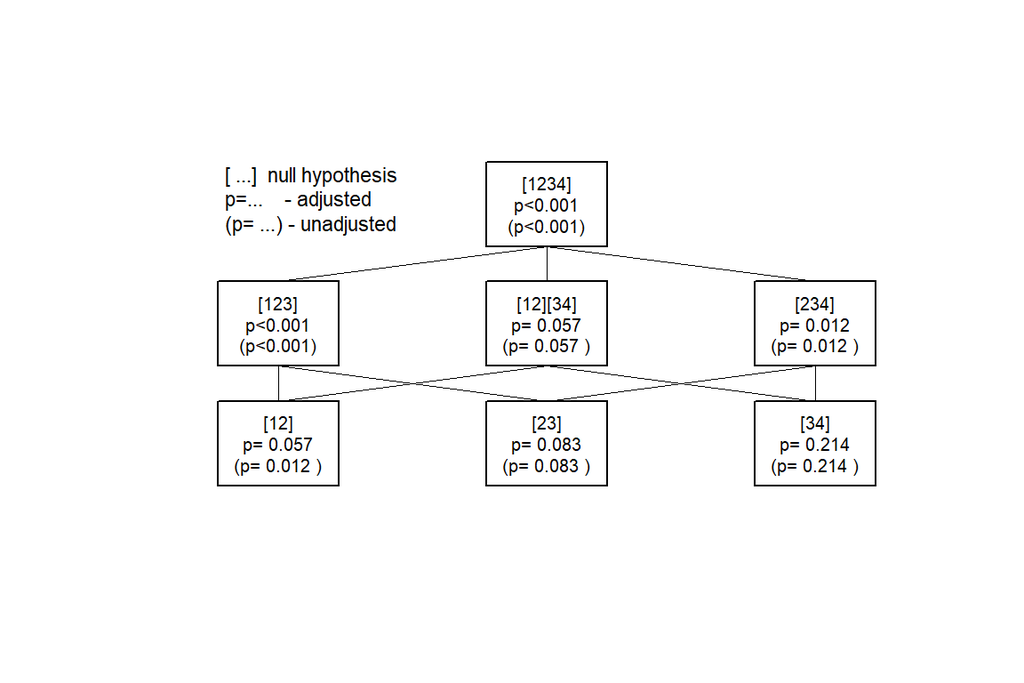

```r
Display(pasi.ctp.J1)
```

## Proportions

The data set **colorectal** contains the response rates from a dose finding study in metastatic colorectal cancer. Two doses of the experimental drug were compared to the standard treatment. The response rates in the two dose groups are compared to the control responder rate using both, the $\chi^2$-test and Fisher’s exact test.

```r
    two.to.first<- IntersectHypotheses(list(1:2,c(1,3)))

    Display(two.to.first,Type="s",main="two vs control",arrow=TRUE)
```

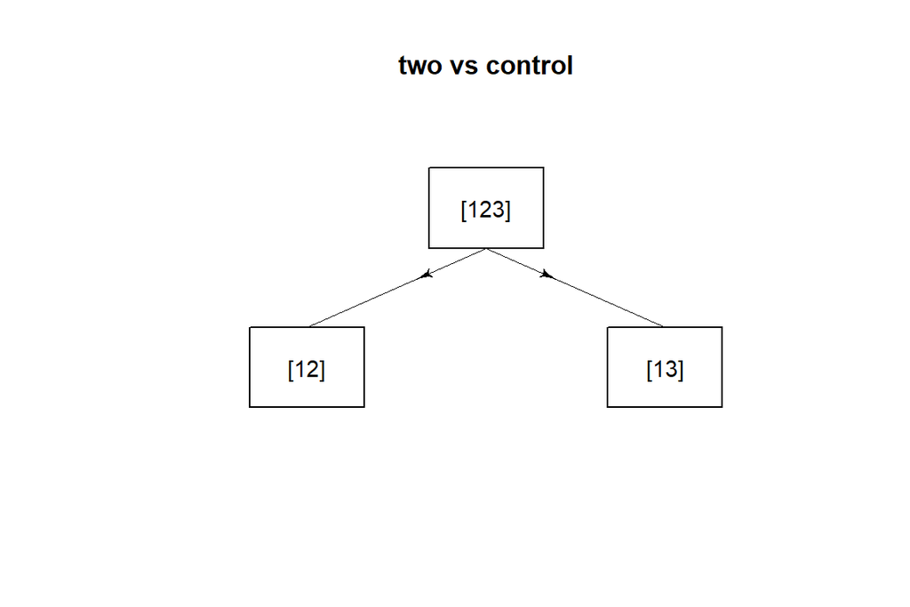

```r
    #The two elementary hypotheses  are tested after comparing the three proportions globally.

    data(colorectal)
    colorectal.ctp <-AnalyseCTP(two.to.first,responder~dose,data=colorectal, test="prob")
    summary(colorectal.ctp)
```

```
##
## Summary of Closed Testing Procedure
## ===================================
##
## Model : responder ~ dose , test : prob
##
## Factor levels: 1=control, 2=low, 3=high
##
## Hypotheses and p-values
## -----------------------
##
##  Hypothesis Level raw p-value adj. p-value
##        [12]     1     0.02018      0.04459
##        [13]     1     0.09877      0.09877
##       [123]     2     0.04459      0.04459
```

```r
    Display(colorectal.ctp,Type="t")
```

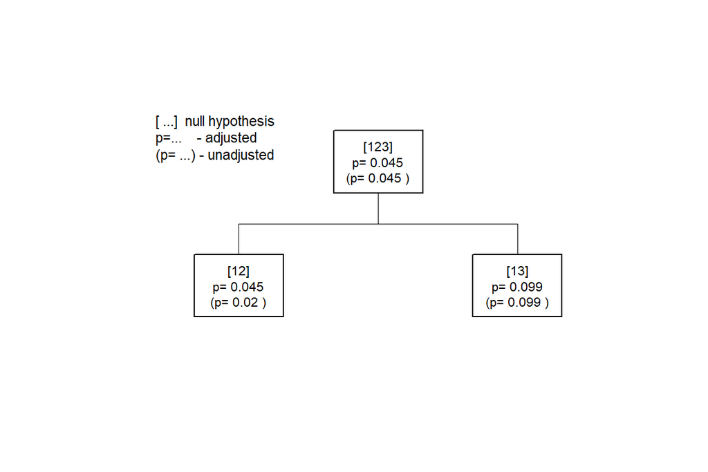

```r
    colorectal.chisq <-AnalyseCTP(two.to.first,responder~dose,data=colorectal, test="chisq")
    summary(colorectal.chisq,digits=1)
```

```
##
## Summary of Closed Testing Procedure
## ===================================
##
## Model : responder ~ dose , test : chisq
##
## Factor levels: 1=control, 2=low, 3=high
##
## Hypotheses and p-values
## -----------------------
##
##  Hypothesis Level raw p-value adj. p-value
##        [12]     1        0.03         0.05
##        [13]     1        0.11         0.11
##       [123]     2        0.05         0.05
```

## Survival Analysis with the logrank test

This example uses the sample dataset **ovarian** from the package **survival**. The overall survival curves of the two treatmens *rx* do not differ significantly:

```r
library(survival)
       data(ovarian)

       print(survdiff(Surv(futime,fustat)~rx, data=ovarian))
```

```
## Call:
## survdiff(formula = Surv(futime, fustat) ~ rx, data = ovarian)
##
##       N Observed Expected (O-E)^2/E (O-E)^2/V
## rx=1 13        7     5.23     0.596      1.06
## rx=2 13        5     6.77     0.461      1.06
##
##  Chisq= 1.1  on 1 degrees of freedom, p= 0.3
```

Together with the performance subgroups *ecog=1* and *ecog=2* , a factor “subgroups” defined by the combinations of the performance measure *ecog.ps* and the treatment *rx*.

```r
        ovarian$subgroups <- as.factor(10*ovarian$ecog.ps+ovarian$rx)
        print(head(ovarian))
```

```
##   futime fustat     age resid.ds rx ecog.ps subgroups
## 1     59      1 72.3315        2  1       1        11
## 2    115      1 74.4932        2  1       1        11
## 3    156      1 66.4658        2  1       2        21
## 4    421      0 53.3644        2  2       1        12
## 5    431      1 50.3397        2  1       1        11
## 6    448      0 56.4301        1  1       2        21
```

Then, the treatment differences within the performance subgroups ecog=1 and ecog=2 are compared. I.e. the elementary hypotheses are *subgroup11=subgroup12* and *subgroup21=subgroup22* or $\{(1,2),(3,4)\}$.

```r
        comb.sub  <- IntersectHypotheses(list(c(1,2),c(3,4)))
        #Display(comb.sub)
        ovar.ctp  <-AnalyseCTP(comb.sub,Surv(futime,fustat)~subgroups, ovarian, test="lgrank")
        summary(ovar.ctp)
```

```
##
## Summary of Closed Testing Procedure
## ===================================
##
## Model : Surv(futime, fustat) ~ subgroups , test : lgrank
##
## Factor levels: 1=11, 2=12, 3=21, 4=22
##
## Hypotheses and p-values
## -----------------------
##
##  Hypothesis Level raw p-value adj. p-value
##        [12]     1      0.1119       0.3171
##        [34]     1      0.8434       0.8434
##    [12][34]     2      0.3171       0.3171
```

```r
        Display(ovar.ctp)
```

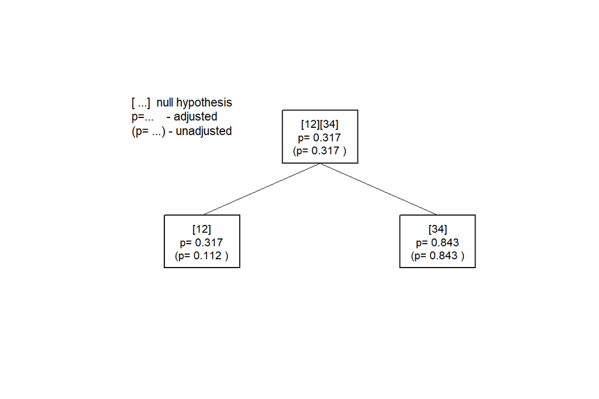

## Comparing means when a covariate is included

In a study with diabetes type II patients (dataset **glucose**), three doses of a drug are compared to a placebo. The primary variable is the change of fasting plasma glucose from baseline. Fasting plasma glucose at baseline is included into the model as covariate (only implmented for linear models).

```r
                data(glucose)
                glucose.ctp <- AnalyseCTP(three.to.first,GLUCOSE.CHANGE~GLUCOSE.BLA+DOSE,
                                         data=glucose, factor.name="DOSE")
                summary(glucose.ctp)
```

```
##
## Summary of Closed Testing Procedure
## ===================================
##
## Model : GLUCOSE.CHANGE ~ GLUCOSE.BLA + DOSE , test : F
##
## Factor levels: 1=PLACEBO, 2=LOW, 3=MEDIUM, 4=HIGH
##
## Hypotheses and p-values
## -----------------------
##
##  Hypothesis Level raw p-value adj. p-value
##        [12]     1   6.033e-02    6.033e-02
##        [13]     1   7.086e-05    3.536e-04
##        [14]     1   6.917e-05    3.464e-04
##       [123]     2   3.536e-04    3.536e-04
##       [124]     2   3.464e-04    3.464e-04
##       [134]     2   2.407e-05    7.375e-05
##      [1234]     3   7.375e-05    7.375e-05
```

```r
                Display(glucose.ctp,Type="s")
```

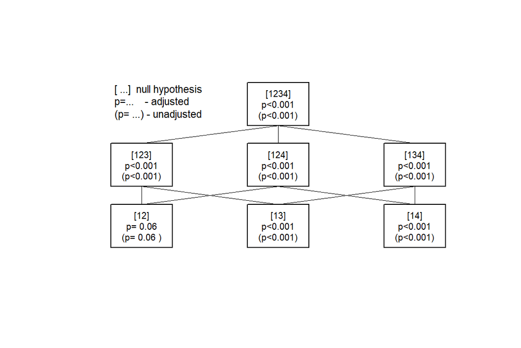

## Large hypothesis trees

Whith an increasing number of hypotheses to test, the graphical display may become quite confusing:

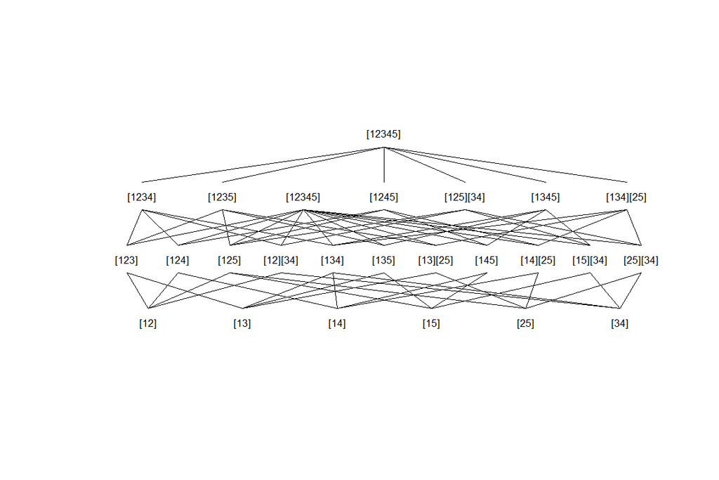

```r
                G <- factor(rep(1:5,each=4) )
                y <- rnorm(20)
                Y <- data.frame(G,y)

xxx <- IntersectHypotheses(list(1:2,c(1,3),c(1,4),c(1,5),c(2,5),c(3,4)))
summary(xxx)
## New names:
## * hyp.no -> hyp.no...2
## * hyp.no -> hyp.no...5
##
## Hypotheses to be tested
## =======================
##
##  hyp.no level hypothesis.name
##       1     1            [12]
##       2     1            [13]
##       3     1            [14]
##       4     1            [15]
##       5     1            [25]
##       6     1            [34]
##       1     2           [123]
##       2     2           [124]
##       3     2           [125]
##       4     2        [12][34]
##       5     2           [134]
##       6     2           [135]
##       7     2        [13][25]
##       8     2           [145]
##       9     2        [14][25]
##      10     2        [15][34]
##      11     2        [25][34]
##       1     3          [1234]
##       2     3          [1235]
##       3     3         [12345]
##       4     3          [1245]
##       5     3       [125][34]
##       6     3          [1345]
##       7     3       [134][25]
##       1     4         [12345]
##
## Connection structure of the hypotheses
## ======================================
##
##  Level            Connection
##      1         [12] -> [123]
##      1         [12] -> [124]
##      1         [12] -> [125]
##      1      [12] -> [12][34]
##      1         [13] -> [123]
##      1         [13] -> [134]
##      1         [13] -> [135]
##      1      [13] -> [13][25]
##      1         [14] -> [124]
##      1         [14] -> [134]
##      1         [14] -> [145]
##      1      [14] -> [14][25]
##      1         [15] -> [125]
##      1         [15] -> [135]
##      1         [15] -> [145]
##      1      [15] -> [15][34]
##      1         [25] -> [125]
##      1      [25] -> [13][25]
##      1      [25] -> [14][25]
##      1      [25] -> [25][34]
##      1      [34] -> [12][34]
##      1         [34] -> [134]
##      1      [34] -> [15][34]
##      1      [34] -> [25][34]
##      2       [123] -> [1234]
##      2       [123] -> [1235]
##      2      [123] -> [12345]
##      2       [124] -> [1234]
##      2      [124] -> [12345]
##      2       [124] -> [1245]
##      2       [125] -> [1235]
##      2      [125] -> [12345]
##      2       [125] -> [1245]
##      2    [125] -> [125][34]
##      2    [12][34] -> [1234]
##      2   [12][34] -> [12345]
##      2 [12][34] -> [125][34]
##      2       [134] -> [1234]
##      2      [134] -> [12345]
##      2       [134] -> [1345]
##      2    [134] -> [134][25]
##      2       [135] -> [1235]
##      2      [135] -> [12345]
##      2       [135] -> [1345]
##      2    [13][25] -> [1235]
##      2   [13][25] -> [12345]
##      2 [13][25] -> [134][25]
##      2      [145] -> [12345]
##      2       [145] -> [1245]
##      2       [145] -> [1345]
##      2   [14][25] -> [12345]
##      2    [14][25] -> [1245]
##      2 [14][25] -> [134][25]
##      2   [15][34] -> [12345]
##      2 [15][34] -> [125][34]
##      2    [15][34] -> [1345]
##      2   [25][34] -> [12345]
##      2 [25][34] -> [125][34]
##      2 [25][34] -> [134][25]
##      3    [12345] -> [12345]
##      3     [1234] -> [12345]
##      3     [1235] -> [12345]
##      3     [1245] -> [12345]
##      3  [125][34] -> [12345]
##      3     [1345] -> [12345]
##      3  [134][25] -> [12345]
Display(xxx)
```

## “External” p-values

It is possible to use:

- **IntersectHypotheses** to create the closure set and **Display** to plot the corresponding hypothesis tree.
- Calculate the p-values for the local hypotheses with other functions or software.
- Import these p-values.
- Use **Adjust_raw** to calculte the adjusted p- values. **Adjust_raw** delivers an object of class **ctp**.
- Use **summary** and **Display** on this object.

```r
    xxx <- IntersectHypotheses(list(1:2,c(1,3),c(1,4)))
  xxx$hypothesis
## [[1]]
## [[1]][[1]]
## [1] 1 2
##
## [[1]][[2]]
## [1] 1 3
##
## [[1]][[3]]
## [1] 1 4
##
##
## [[2]]
## [[2]][[1]]
## [1] 1 2 3
##
## [[2]][[2]]
## [1] 1 2 4
##
## [[2]][[3]]
## [1] 1 3 4
##
##
## [[3]]
## [[3]][[1]]
## [1] 1 2 3 4
  data.frame(xxx$hypnames)
```

```
##   hyp.no level hypothesis.name
## 1      1     1            [12]
## 2      2     1            [13]
## 3      3     1            [14]
## 4      1     2           [123]
## 5      2     2           [124]
## 6      3     2           [134]
## 7      1     3          [1234]
```

```r
  xxx$hypnames
```

```
##   hyp.no level hypothesis.name
## 1      1     1            [12]
## 2      2     1            [13]
## 3      3     1            [14]
## 4      1     2           [123]
## 5      2     2           [124]
## 6      3     2           [134]
## 7      1     3          [1234]
```

```r
  p.val<-c(0.05,0.04,0.02,0.08,0.03,0.03,0.04)

  Adjust_raw(xxx, p.val)
```

[output not shown]

[output cut: 48 more lines]

```
## $pvalues
##   hyp.no level hypothesis.name pvalue pvalue.adj
## 1      1     1            [12]   0.05       0.08
## 2      2     1            [13]   0.04       0.08
## 3      3     1            [14]   0.02       0.04
## 4      1     2           [123]   0.08       0.08
## 5      2     2           [124]   0.03       0.04
## 6      3     2           [134]   0.03       0.04
## 7      1     3          [1234]   0.04       0.04
##
## $info
## NULL
##
## attr(,"class")
## [1] "ctp"
```

```r
    # the vector of p-values calculated by another software
    # you may supply the hypothesis names as names of the vector

  result <- Adjust_raw(ctp.struc=three.to.first, p.value=p.val)

    summary(result)
```

```
##
## Summary of Closed Testing Procedure
## ===================================
##
## Hypotheses and p-values
## -----------------------
##
##  Hypothesis Level raw p-value adj. p-value
##        [12]     1        0.05         0.08
##        [13]     1        0.04         0.08
##        [14]     1        0.02         0.04
##       [123]     2        0.08         0.08
##       [124]     2        0.03         0.04
##       [134]     2        0.03         0.04
##      [1234]     3        0.04         0.04
```

```r
    # details may be documented

    result<-Adjust_raw(ctp.struc=three.to.first, p.value=p.val
              ,dataset.name="mydata", factor.name="treatment"
              ,factor.levels=c("A","B","C","D"), model=y~treatment
              ,test.name="F")

    summary(result)
```

```
##
## Summary of Closed Testing Procedure
## ===================================
##
## Model : y ~ treatment , test : F
##
## Factor levels: 1=A, 2=B, 3=C, 4=D
##
## Hypotheses and p-values
## -----------------------
##
##  Hypothesis Level raw p-value adj. p-value
##        [12]     1        0.05         0.08
##        [13]     1        0.04         0.08
##        [14]     1        0.02         0.04
##       [123]     2        0.08         0.08
##       [124]     2        0.03         0.04
##       [134]     2        0.03         0.04
##      [1234]     3        0.04         0.04
```

```r
    Display(result)
```

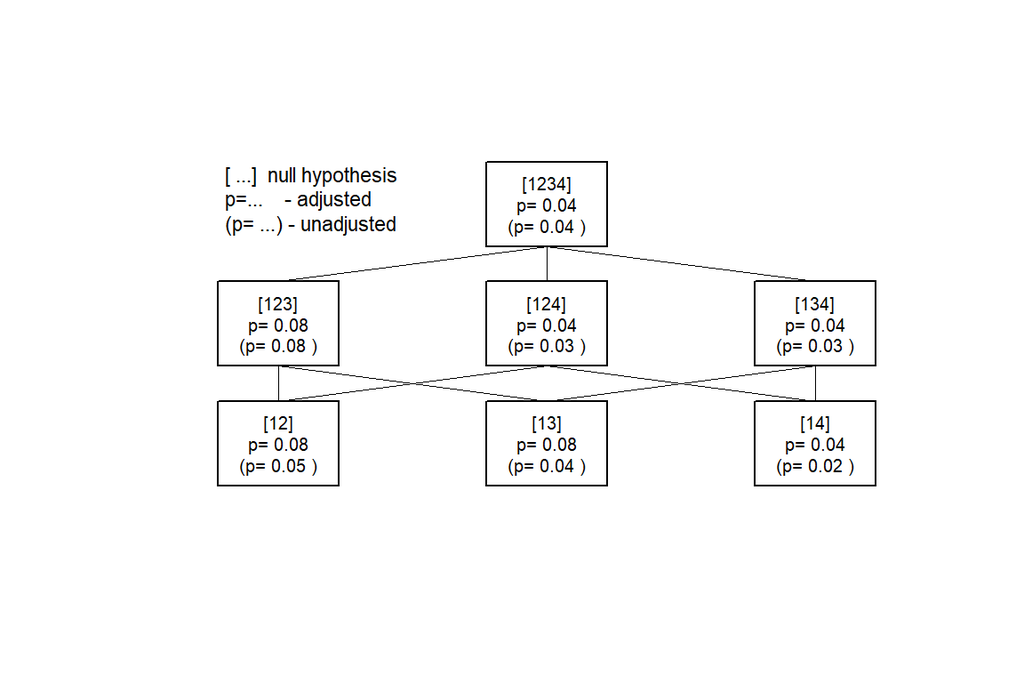

## References

Bauer, Peter. 1991. “Multiple Testing in Clinical Trials.” *Statistics in Medicine* 10 (4): 261–63.

Bretz, Frank, Hothorn, T., and Westfall,P. 2011. *Multiple Comparisons Using R*. CRC Press.

Dmitrienko, Alex, Tamhane, A., and Bretz, F. 2010. *Multiple Testing Problems in Pharmaceutical Statistics*. Chapman & Hall.

Marcus, Ruth, Peritz, E., and Gabriel, K.R. 1976. “On Closed Testing Procedures with Special Reference to Ordered Analysis of Variance.” *Biometrika* 63: 655–60.